## Analysis Over the efficiency of a multi-threaded implementation of the QuickSort algorithm on multi-core machines, we are studying the time that will take every different Method individual, and if there is relation between the size of array and the time for sorting, you can find the data we use in folder data.

```r
library(ggplot2)
library(dplyr)
library(tidyr)

df <- read.csv("data/measurements_03_47.csv", header = T)
df$Type <- gsub("\\s+", "", df$Type)
head(df)
```

```
##   Size       Type     Time
## 1  100 Sequential 0.000010
## 2  100   Parallel 0.004024
## 3  100   Built-in 0.000013
## 4  100 Sequential 0.000010
## 5  100   Parallel 0.004448
## 6  100   Built-in 0.000014
```

```r
summary(df)
```

```
##       Size             Type                Time
##  Min.   :    100   Length:75          Min.   :0.000009
##  1st Qu.:   1000   Class :character   1st Qu.:0.000210
##  Median :  10000   Mode  :character   Median :0.016149
##  Mean   : 222220                      Mean   :0.051255
##  3rd Qu.: 100000                      3rd Qu.:0.043877
##  Max.   :1000000                      Max.   :0.242869
```

```r
print(df)
```

```
##       Size       Type     Time
## 1      100 Sequential 0.000010
## 2      100   Parallel 0.004024
## 3      100   Built-in 0.000013
## 4      100 Sequential 0.000010
## 5      100   Parallel 0.004448
## 6      100   Built-in 0.000014
## 7      100 Sequential 0.000009
## 8      100   Parallel 0.003384
## 9      100   Built-in 0.000013
## 10     100 Sequential 0.000010
## 11     100   Parallel 0.003738
## 12     100   Built-in 0.000012
## 13     100 Sequential 0.000010
## 14     100   Parallel 0.003133
```

[output cut: 61 more lines]

### here we calculate the mean and the standard deviation, the confidence interval for time .

```r
dfsum <- group_by(df, Size, Type) %>%
  summarise(num = n(), mean = mean(Time), sd = sd(Time), se = 2*sd/sqrt(num),.groups = 'drop')
```

```r
print(dfsum)
```

```
## # A tibble: 15 × 6
##       Size Type         num      mean          sd          se
##      <int> <chr>      <int>     <dbl>       <dbl>       <dbl>
##  1     100 Built-in       5 0.0000126 0.00000114  0.00000102
##  2     100 Parallel       5 0.00375   0.000519    0.000464
##  3     100 Sequential     5 0.0000098 0.000000447 0.000000400
##  4    1000 Built-in       5 0.000208  0.00000383  0.00000343
##  5    1000 Parallel       5 0.0176    0.00338     0.00302
##  6    1000 Sequential     5 0.000128  0.00000110  0.000000980
##  7   10000 Built-in       5 0.00172   0.0000117   0.0000104
##  8   10000 Parallel       5 0.0174    0.000970    0.000868
##  9   10000 Sequential     5 0.00170   0.0000467   0.0000418
## 10  100000 Built-in       5 0.0204    0.000126    0.000113
## 11  100000 Parallel       5 0.0478    0.00361     0.00323
## 12  100000 Sequential     5 0.0199    0.000141    0.000126
## 13 1000000 Built-in       5 0.242     0.000630    0.000563
## 14 1000000 Parallel       5 0.162     0.00580     0.00519
## 15 1000000 Sequential     5 0.234     0.00350     0.00313
```

### here we will plot the data with different colors for each unique value in the type column.

#### first graph size with time without linear regression

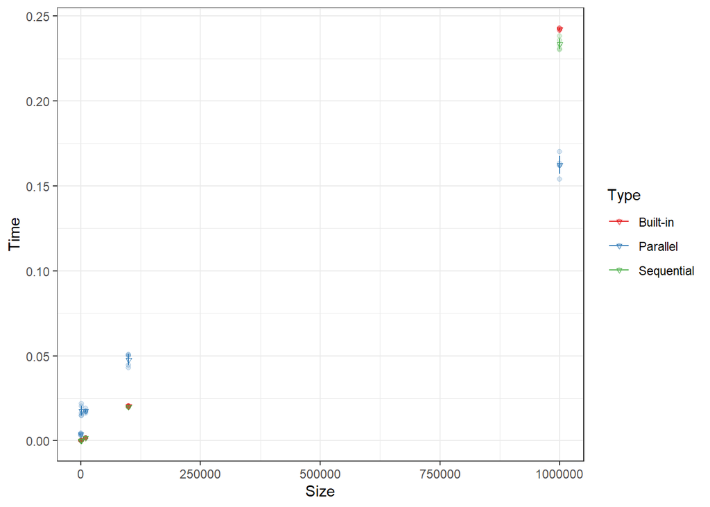

```r
ggplot(df,aes(x=Size,y=Time,color=Type)) +
  scale_color_brewer(palette="Set1") + theme_bw() +
  geom_jitter(alpha=.2,position=position_jitter(width = 0.1)) +
  geom_errorbar(data=dfsum,width=0.1, aes(y=mean,ymin=mean-se,ymax=mean+se)) +
  geom_point(data=dfsum,shape=25, size=1, aes(y=mean,color=Type))
```

#### second graph size and time with linear regression

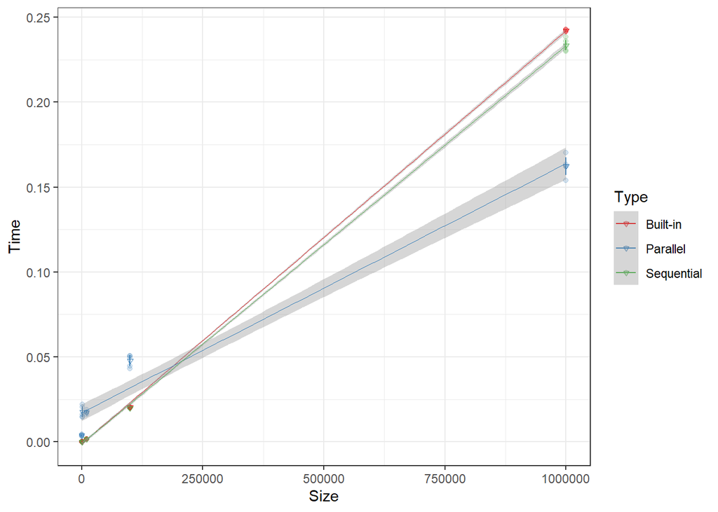

```r
ggplot(df,aes(x=Size,y=Time,color=Type)) +
  scale_color_brewer(palette="Set1") + theme_bw() +
  geom_jitter(alpha=.2,position = position_jitter(width = 0.1)) +
  geom_errorbar(data=dfsum,width=0.1, aes(y=mean,ymin=mean-se,ymax=mean+se)) +
  geom_point(data=dfsum,shape=25, size=1, aes(y=mean,color=Type))+
  geom_smooth(method="lm",linewidth=0.1)
```

```r
dfforlm = df %>% filter(Type == "Parallel")
print(dfforlm)
```

```
##       Size     Type     Time
## 1      100 Parallel 0.004024
## 2      100 Parallel 0.004448
## 3      100 Parallel 0.003384
## 4      100 Parallel 0.003738
## 5      100 Parallel 0.003133
## 6     1000 Parallel 0.020407
## 7     1000 Parallel 0.022003
## 8     1000 Parallel 0.016149
## 9     1000 Parallel 0.014594
## 10    1000 Parallel 0.014905
## 11   10000 Parallel 0.018943
## 12   10000 Parallel 0.016226
## 13   10000 Parallel 0.017348
## 14   10000 Parallel 0.017302
## 15   10000 Parallel 0.017386
## 16  100000 Parallel 0.050548
## 17  100000 Parallel 0.043119
## 18  100000 Parallel 0.050735
## 19  100000 Parallel 0.049806
## 20  100000 Parallel 0.044636
## 21 1000000 Parallel 0.162221
## 22 1000000 Parallel 0.162137
## 23 1000000 Parallel 0.163279
## 24 1000000 Parallel 0.170237
## 25 1000000 Parallel 0.153896
```

### we will try to use linear regression for there type of data wth simple function.

```r
reg <- lm(Time ~ Size,data = dfforlm)
summary(reg)
```

```
##
## Call:
## lm(formula = Time ~ Size, data = dfforlm)
##
## Residuals:
##       Min        1Q    Median        3Q       Max
## -0.014052 -0.002723 -0.001290  0.004686  0.018888
##
## Coefficients:
##              Estimate Std. Error t value Pr(>|t|)
## (Intercept) 1.717e-02  2.364e-03   7.263 2.16e-07 ***
## Size        1.468e-07  5.260e-09  27.904  < 2e-16 ***
## ---
## Signif. codes:  0 '***' 0.001 '**' 0.01 '*' 0.05 '.' 0.1 ' ' 1
##
## Residual standard error: 0.01027 on 23 degrees of freedom
## Multiple R-squared:  0.9713, Adjusted R-squared:  0.9701
## F-statistic: 778.6 on 1 and 23 DF,  p-value: < 2.2e-16
```

### so what we knew from the LR model is that we can see the estimated value for slope and the constant are quite small also what is the range for these values +-std error, we can see the test like F test, and the p-value is too small means reject the null hypothesis ( consider the coefficients zero)

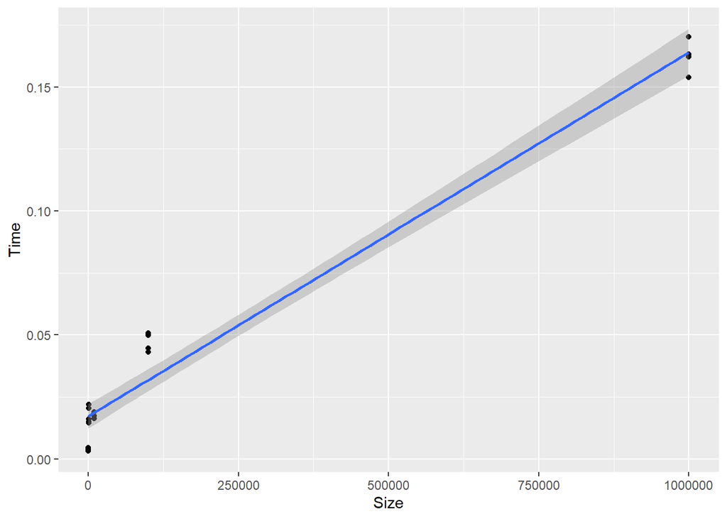

```r
ggplot(dfforlm,aes(x = Size, y = Time)) + geom_point() + stat_smooth(method = "lm", formula = y ~ x,geom = "smooth")
```

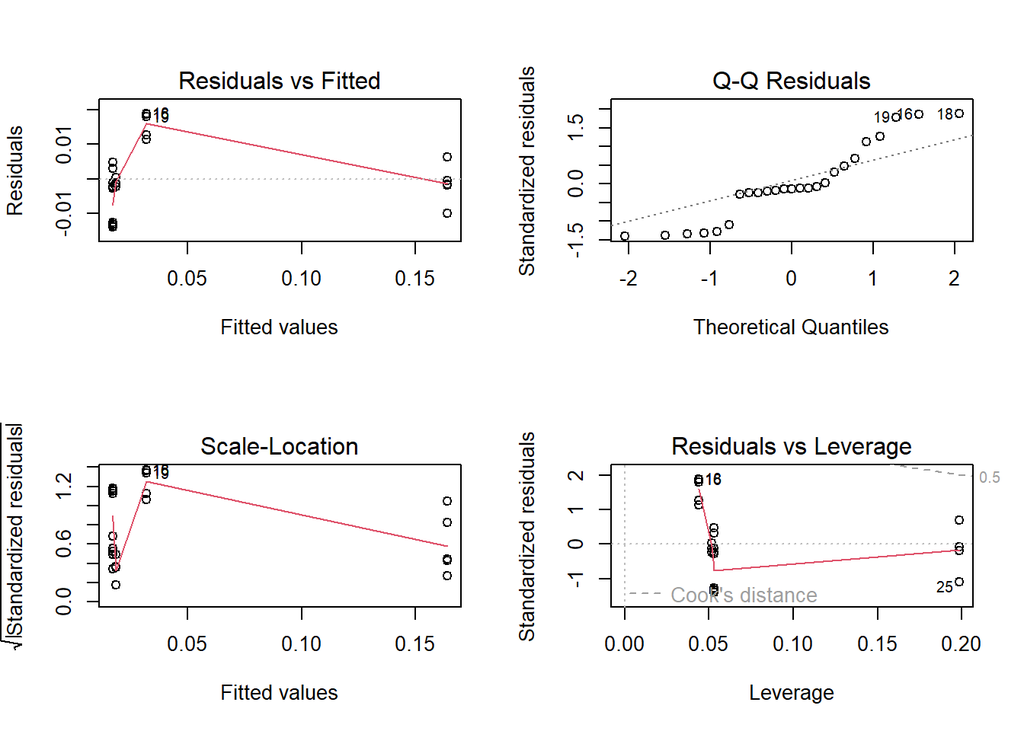

```r
par(mfrow=c(2,2));plot(reg);par(mfrow=c(1,1))
```

### from the above graph fitted value vs residuals I am really not sure here is there pattern or not we need more measurements for this situation in different sizes like n the middel.

### now let see another function with linear regression model but now we make it more oriented to our problem since the complexity for the quicksort it is n log n aparroximatly.

```r
reg2 <- lm(Time ~ log(Size)+Size^2,data = dfforlm)
summary(reg2)
```

```
##
## Call:
## lm(formula = Time ~ log(Size) + Size^2, data = dfforlm)
##
## Residuals:
##        Min         1Q     Median         3Q        Max
## -0.0087444 -0.0011620 -0.0002334  0.0024763  0.0083303
##
## Coefficients:
##               Estimate Std. Error t value Pr(>|t|)
## (Intercept) -1.437e-02  4.022e-03  -3.572   0.0017 **
## log(Size)    4.042e-03  4.920e-04   8.214  3.8e-08 ***
## Size         1.212e-07  4.101e-09  29.546  < 2e-16 ***
## ---
## Signif. codes:  0 '***' 0.001 '**' 0.01 '*' 0.05 '.' 0.1 ' ' 1
##
## Residual standard error: 0.005209 on 22 degrees of freedom
## Multiple R-squared:  0.9929, Adjusted R-squared:  0.9923
## F-statistic:  1548 on 2 and 22 DF,  p-value: < 2.2e-16
```

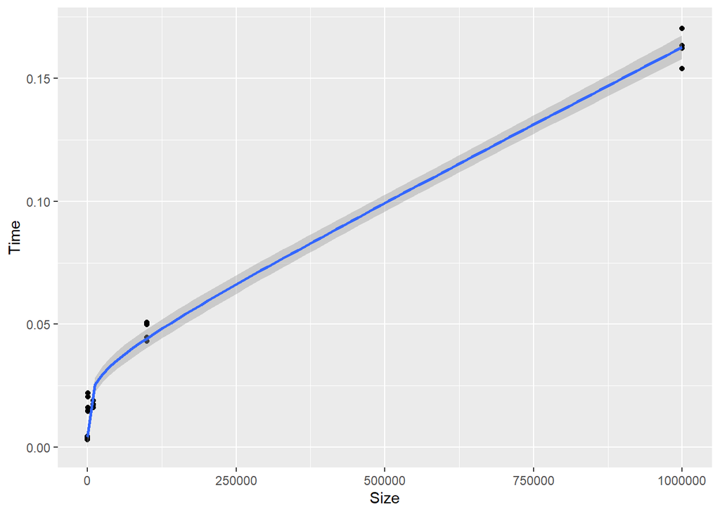

```r
ggplot(dfforlm,aes(x = Size, y = Time)) + geom_point() + stat_smooth(method = "lm", formula = y ~ log(x)+x^2,geom = "smooth")
```

### we can see how is the model fit the points very well but can we consider the model good ? maybe , but let see the residual points and the summary of the model.

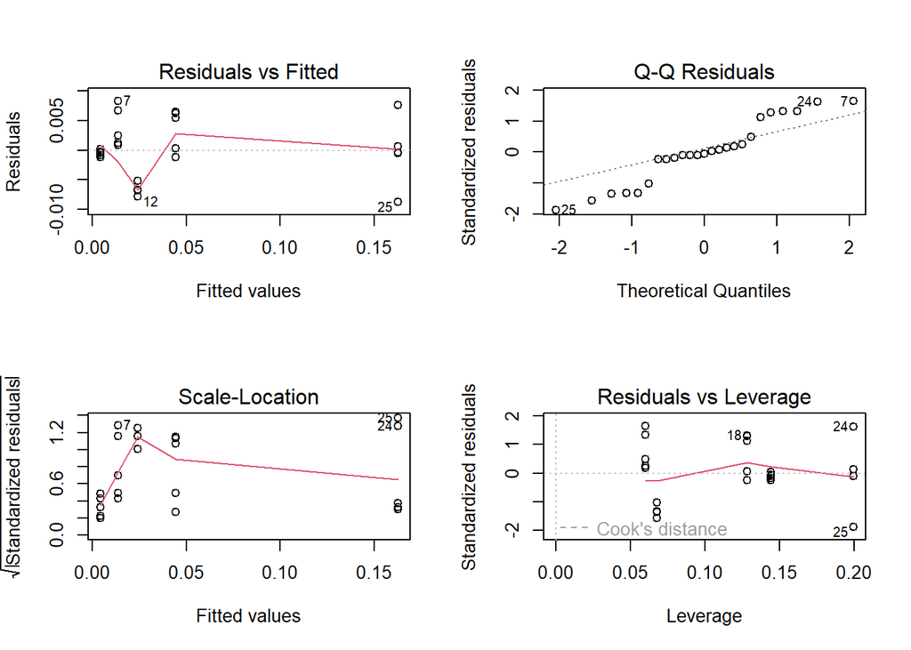

```r
par(mfrow=c(2,2));plot(reg2);par(mfrow=c(1,1))
```

### we will try with Sequential method for QuickSort Algorithm.

### filter first on type column.

```r
dfforlm2 = df %>% filter(Type == "Sequential")
print(dfforlm2)
```

```
##       Size       Type     Time
## 1      100 Sequential 0.000010
## 2      100 Sequential 0.000010
## 3      100 Sequential 0.000009
## 4      100 Sequential 0.000010
## 5      100 Sequential 0.000010
## 6     1000 Sequential 0.000128
## 7     1000 Sequential 0.000126
## 8     1000 Sequential 0.000128
## 9     1000 Sequential 0.000128
## 10    1000 Sequential 0.000129
## 11   10000 Sequential 0.001774
## 12   10000 Sequential 0.001698
## 13   10000 Sequential 0.001652
## 14   10000 Sequential 0.001680
## 15   10000 Sequential 0.001675
## 16  100000 Sequential 0.020040
## 17  100000 Sequential 0.020004
## 18  100000 Sequential 0.019763
## 19  100000 Sequential 0.019913
## 20  100000 Sequential 0.019726
## 21 1000000 Sequential 0.230648
## 22 1000000 Sequential 0.235778
## 23 1000000 Sequential 0.238383
## 24 1000000 Sequential 0.232921
## 25 1000000 Sequential 0.230096
```

### the linear model algo wwith summary and some graphs about how good our model .

```r
reg3 <- lm(Time ~ Size,data = dfforlm2)
summary(reg3)
```

```
##
## Call:
## lm(formula = Time ~ Size, data = dfforlm2)
##
## Residuals:
##        Min         1Q     Median         3Q        Max
## -0.0032211 -0.0023774  0.0004466  0.0010015  0.0050659
##
## Coefficients:
##               Estimate Std. Error t value Pr(>|t|)
## (Intercept) -1.016e-03  4.583e-04  -2.217   0.0368 *
## Size         2.343e-07  1.020e-09 229.807   <2e-16 ***
## ---
## Signif. codes:  0 '***' 0.001 '**' 0.01 '*' 0.05 '.' 0.1 ' ' 1
##
## Residual standard error: 0.001992 on 23 degrees of freedom
## Multiple R-squared:  0.9996, Adjusted R-squared:  0.9995
## F-statistic: 5.281e+04 on 1 and 23 DF,  p-value: < 2.2e-16
```

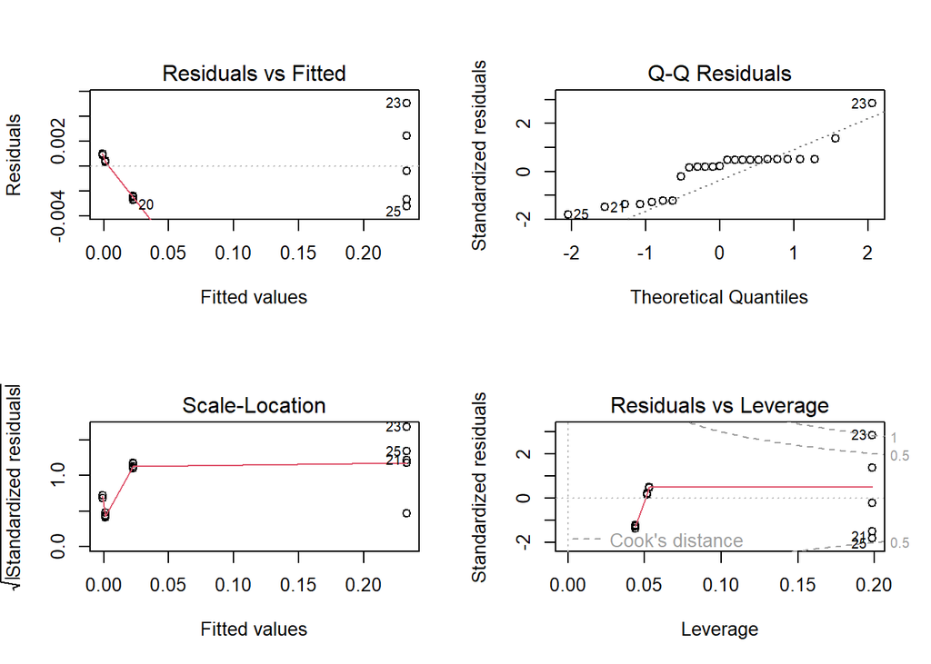

```r
par(mfrow=c(2,2));plot(reg3);par(mfrow=c(1,1))
```

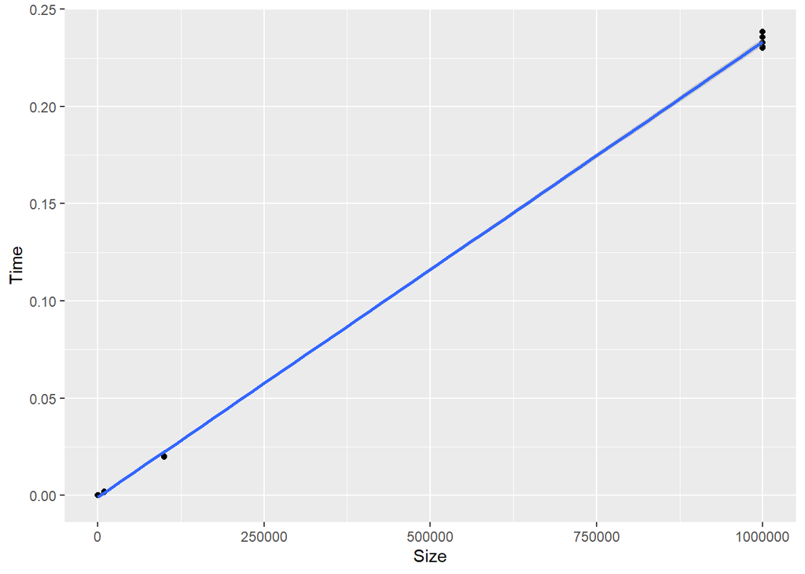

```r
ggplot(dfforlm2,aes(x = Size, y = Time)) + geom_point() + stat_smooth(method = "lm", formula = y ~ x,geom = "smooth")
```

### The linear model with different equation.

```r
reg4 <- lm(Time ~ log(Size)+Size^2,data = dfforlm2)
summary(reg4)
```

```
##
## Call:
## lm(formula = Time ~ log(Size) + Size^2, data = dfforlm2)
##
## Residuals:
##        Min         1Q     Median         3Q        Max
## -0.0033836 -0.0008145 -0.0005586  0.0010073  0.0049034
##
## Coefficients:
##               Estimate Std. Error t value Pr(>|t|)
## (Intercept)  2.948e-03  1.300e-03   2.268  0.03347 *
## log(Size)   -5.080e-04  1.590e-04  -3.195  0.00418 **
## Size         2.376e-07  1.325e-09 179.264  < 2e-16 ***
## ---
## Signif. codes:  0 '***' 0.001 '**' 0.01 '*' 0.05 '.' 0.1 ' ' 1
##
## Residual standard error: 0.001683 on 22 degrees of freedom
## Multiple R-squared:  0.9997, Adjusted R-squared:  0.9997
## F-statistic: 3.698e+04 on 2 and 22 DF,  p-value: < 2.2e-16
```

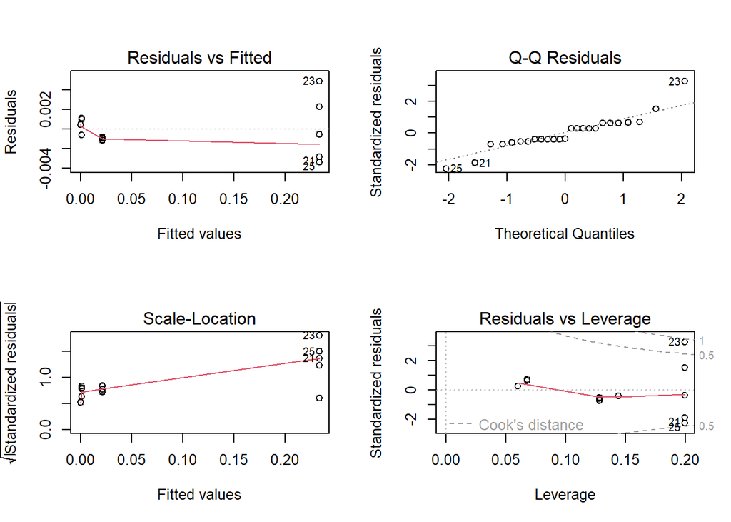

```r
par(mfrow=c(2,2));plot(reg4);par(mfrow=c(1,1))
```

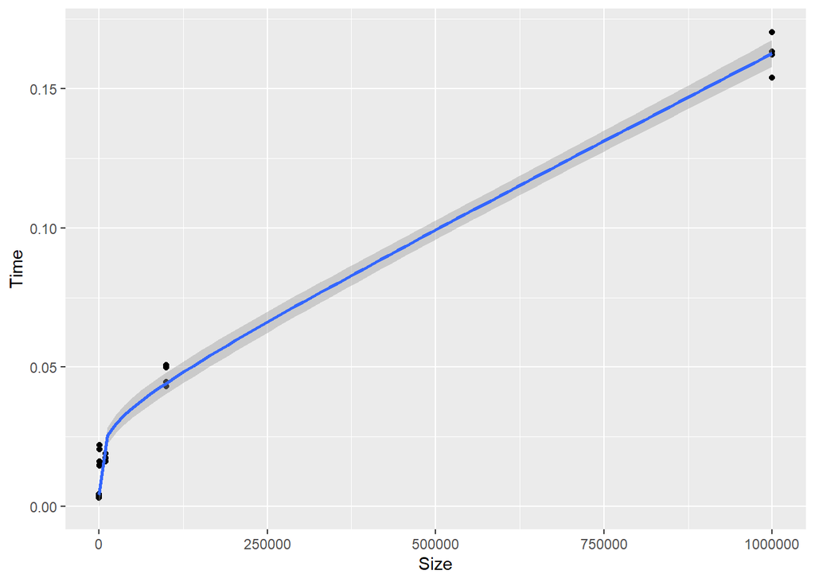

```r
ggplot(dfforlm,aes(x = Size, y = Time)) + geom_point() + stat_smooth(method = "lm", formula = y ~ log(x)+x^2,geom = "smooth")
```